# Assignment 2

STATS 220 Semester One 2022

[figure not shown]

## Introduction

In my report, I decided to focus on the aspect of music listening that takes place over digital streaming services such as spotify and apple music. The report looks at preferred streaming platforms, the amount of time spent streaming music, what devices are used to stream music and how often music is streamed.

## Links to form and data

csv link : https://docs.google.com/spreadsheets/d/e/2PACX-1vQdBUI3bFcJ76ALv3ThJQIZQR1X5oj1FdLUAWboQLenB8lL8LMaQspBGT1gWJv0tAnipILa8jCffiAD/pub?gid=1107961394&single=true&output=csv

Form link : https://forms.gle/cLVxpCXJFqBSrdxt5

## Analytics

The table below shows 5 rows of data that I collected from my peers about their music listening preferences.

| Timestamp | Platform | Time | Genre | Days | Device |
| --- | --- | --- | --- | --- | --- |
| 30/03/2022 15:39:18 | Spotify | 200 | Pop, Indie | 7 | Laptop |
| 30/03/2022 15:42:53 | Spotify | 60 | Classical, Rock | 3 | Smartphone |
| 30/03/2022 15:44:01 | Spotify | 100 | Pop, Classical, Rap, Indie | 7 | Smartphone |
| 30/03/2022 15:45:15 | Spotify | 120 | Pop, Indie | 7 | Smartphone |
| 30/03/2022 15:48:02 | Spotify | 120 | Pop, Indie, Rock | 7 | Smartphone |

Overall, I collected 35 responses to my form.

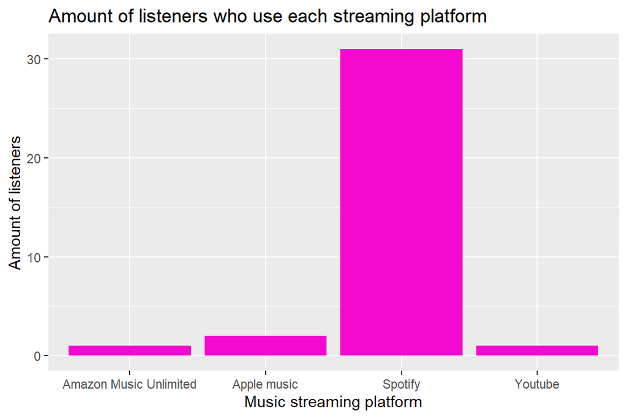

I can see from this bar graph that a high majority of my respondents use spotify as their preferred platform for music streaming.

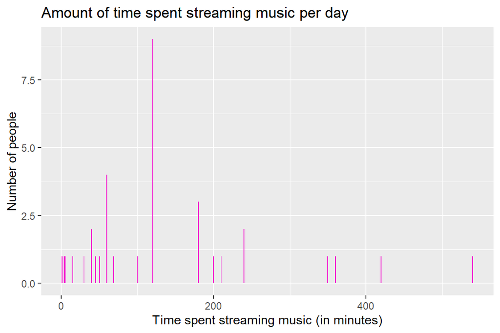

The person who spends the most time streaming music spends 540 minutes streaming music per day, and the person who spends the least time streaming music spends 1 minutes streaming music per day.

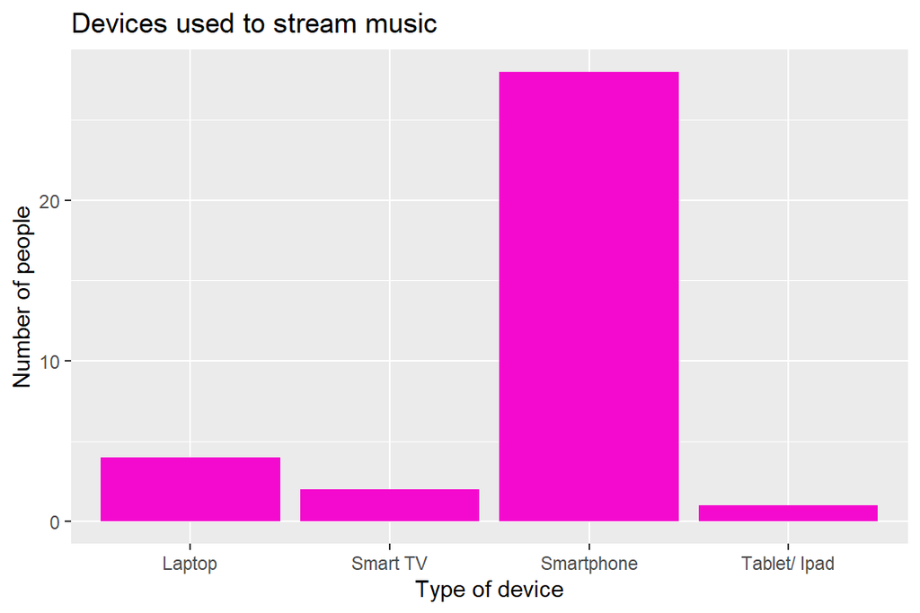

From this graph, we can say there a heavy majority of the respondents use a Smartphone to stream their music.

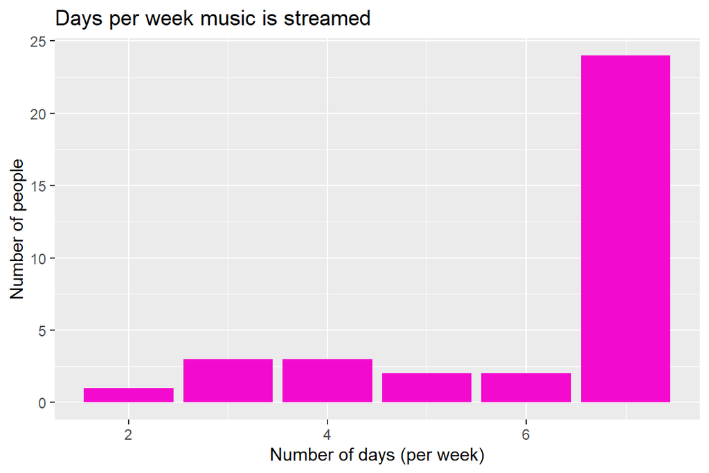

It can be seen that majority of the respondents stream music 7 days per week.

## Learning reflection

An important idea I learnt from this module about creating dynamic reports, is the idea of inline R code and how the values for data you receive when you write the report won’t necessarily be the final values and how this function makes the report adaptable. This is a way to keep reports up to date and relevant with the newest information that is being received.

Two techniques from assignment one I reused, were the use of inserting and image and the use of css to change the background and font. I used the technique of inserting an image to give the reader a visual, as well as verbal indication to what the report will be about and used the css technique to make the report more exciting and engaging to read.

I am excited to go deeper into the world of data visualization and using the optimal type of plot to display the type of data I have. I’m looking forward to learning about the best way possible to do this that is easiest for people to understand what is happening in the data. I am also looking forward to learning about retrieving data from databases and performing manipulations.